# Big Data in Public Health

```r
library(dplyr)
library(foreign)
library(sqldf)
library(stringr)
library(ggplot2)
library(colorRamps)
```

## Data

Caricamento di tutti i file `.csv` presenti nella directory, creazione di altrettanti dataset e assegnazione dei nomi.

```r
# Mantenere il doppio backslash finale
dir = "D:\\Università\\Data Science\\"
setwd(substr(dir, 1, nchar(dir)-1))

# wd senza il doppio backslash finale
setwd(substr(dir, 1, nchar(dir)-1))

# File read
filenames = list.files(path=dir, pattern="*.csv", full.names=TRUE) # lista dei file
ldf = lapply(filenames, read.csv) # read
res = lapply(ldf, summary) # creazione di una lista
names(res) = substr(filenames, nchar(dir)+1, nchar(filenames)-4) #nomi

# Creazione di dataframe partendo dai nomi precedentemente ottenuti
for (i in 1:length(ldf)){
  assign(names(res)[i], as.data.frame(ldf[i]))
}
```

Pre-processing per estrarre il nome del paese dove è presente una stratificazione per regione, filtraggio delle tipologie di cancro e unione dei dataset. Si modifica il nome di alcune variabili per renderli utilizzabili su `sqldf`.

```r
# Se il paese ha la stratificazione per regione, quest'ultimo è contenuto nella colonna del nome
# Si lavorerà in base al nome del paese, quindi si divide il tutto in due colonne
new_col = str_split_fixed(Europe$NAME, "_", 2)
Europe = cbind(Europe, new_col) # aggiungo le nuove colonne
Europe = subset(Europe, select = -NAME) # tolgo la originale
colnames(Europe)[6:7] = c("Country", "Region") # rinomino


### Filtraggio
# Unione casi - popolazione per Cancer_ID=11 (tumore al polmone)
full = sqldf("SELECT *
             FROM Europe_Cases AS ec, Europe_Pops AS ep
             WHERE ec.REGISTRY=ep.REGISTRY AND ec.SEX=ep.SEX AND ec.YEAR=ep.YEAR
             AND Cancer=11")

# Si eliminano le colonne duplicate
full = full[, c(1:ncol(Europe_Cases), (ncol(Europe_Cases)+4):ncol(full))]

# Rinominazione
# Un nome con "+" al suo interno non è considerato valido dalla funzione sqldf
colnames(full)[ncol(Europe_Cases)-1] = "N85"
colnames(full)[ncol(Europe_Cases)+1] = "PopTotal"
colnames(full)[ncol(full)] = "P85"

# Merge con Europe per il nome del paese
full = merge(full, Europe, by.x="REGISTRY", by.y="REGISTRY")


# Somma per Paese/Anno del numero di casi e della popolazione per fasce d'età
# Non si considerano gli N_UNK
full = sqldf("SELECT Country, Year,
             SUM(Total)-SUM(N_UNK) AS Total, SUM(N0_4) AS N0_4, SUM(N5_9) AS N5_9,
             SUM(N10_14) AS N10_14, SUM(N15_19) AS N15_19, SUM(N20_24) AS N20_24,
             SUM(N25_29) AS N25_29, SUM(N30_34) AS N30_34, SUM(N35_39) AS N35_39,
             SUM(N40_44) AS N40_44, SUM(N45_49) AS N45_49, SUM(N50_54) AS N50_54,
             SUM(N55_59) AS N55_59, SUM(N60_64) AS N60_64, SUM(N65_69) AS N65_69,
             SUM(N70_74) AS N70_74, SUM(N75_79) AS N75_79, SUM(N80_84) AS N80_84,
             SUM(N85) AS N85, SUM(N_UNK),
             SUM(PopTotal) AS PopTotal, SUM(P0_4) AS P0_4, SUM(P5_9) AS P5_9,
             SUM(P10_14) AS P10_14, SUM(P15_19) AS P15_19, SUM(P20_24) AS P20_24,
             SUM(P25_29) AS P25_29, SUM(P30_34) AS P30_34, SUM(P35_39) AS P35_39,
             SUM(P40_44) AS P40_44, SUM(P45_49) AS P45_49, SUM(P50_54) AS P50_54,
             SUM(P55_59) AS P55_59, SUM(P60_64) AS P60_64, SUM(P65_69) AS P65_69,
             SUM(P70_74) AS P70_74, SUM(P75_79) AS P75_79, SUM(P80_84) AS P80_84,
             SUM(P85) AS P85
             FROM full
             WHERE Country!='Slovenia'
             GROUP BY Country, Year")
```

## Calcolo dei valori crudi e dell’ASR

Calcolo dei crude rates.

```r
# Age stratified crude rates
RI = full[, c(1:3, 23)]
RI = cbind(RI, round((100000*full[, 4:21])/full[, 24:41], 3)) # calcolo

# Rinomino le colonne
names(RI)[3:ncol(RI)] = c("Cases", "Pop", "0-4", "5-9", "10-14", "15-19", "20-24", "25-29", "30-34", "35-39",
                          "40-44", "45-49", "50-54", "55-59", "60-64", "65-69", "70-74",
                          "75-79", "80-84", "85")

RI = cbind(RI, full[, 24:41]) # Aggiungo i valori di popolazione per fascia d'età
ratio_pop = (RI[, 23:40])/RI[, 4] # Proporzione di popolazione per fascia d'età

# Calcolo del crude rate
# Rate moltiplicati per la proporzione di popolazione
crude = cbind(RI[, 1:4], round((RI[, 5:22]*ratio_pop[, 1:18]), 3))
crude = cbind(crude, rowSums(crude[1:nrow(crude), 5:22]))
names(crude)[23] = "Crude"
```

Calcolo dell’ASR prendendo come riferimento la popolazione standard fornita nel `.csv`.

```r
### Standardizzazione
# Popolazione standard
df = as.data.frame(rbind(as.integer(std_world_pop18classes[, 2])))

# Trasformato in un vettore per semplicità
vect = c()
for (i in 1:length(df)){
  vect[i] = df[[i]]
}

# Calcolo ASR
# Divisione del crude rate per 100'000
temp_standard = RI
temp_standard = cbind(temp_standard[, 1:4], temp_standard[, 5:22]/100000)

# Somma dei valori di riga (singole fasce d'età) per ottenere l'ASR per ogni riga
ASR_vect =  c()
for (i in 1:nrow(temp_standard)){
  ASR_vect[i] = sum(temp_standard[i, 5:22]*vect)
}
temp_standard = cbind(temp_standard, ASR_vect) # valori standardizzati
```

## Visualizzazioni

Visualizzazione dei valori non standardizzati per i primi tre e gli ultimi tre paesi europei per HDI; in aggiunta anche i principali cinque stati europei.

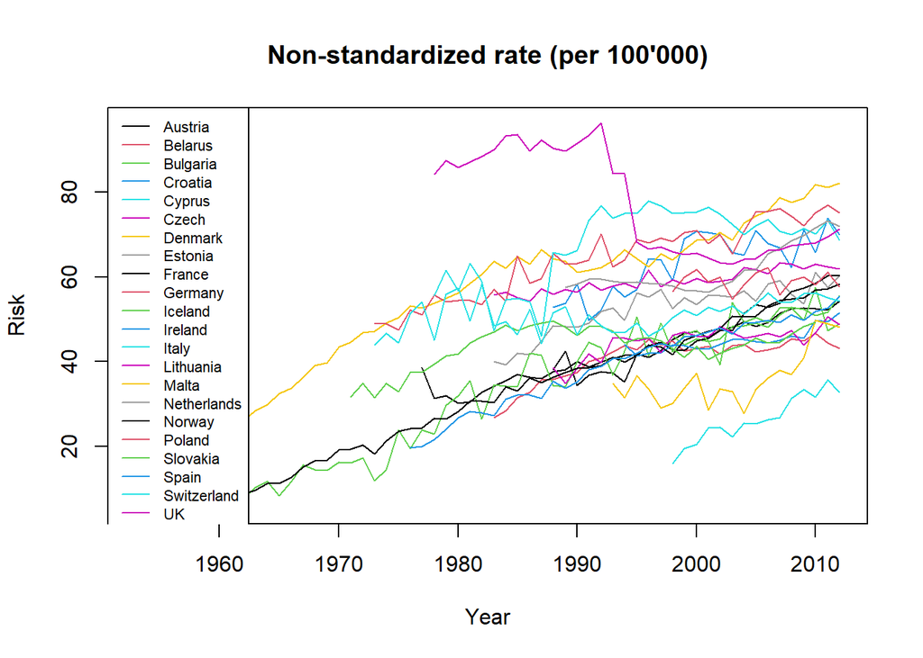

```r
# Plot iniziale della Austria
aut_m = crude[which(crude$Country=="Austria"), ]
plot(aut_m$YEAR, aut_m$Crude, type="l",
     ylim=c(min(crude$Crude), max(crude$Crude)),
     xlim=c(min(crude$YEAR), max(crude$YEAR)),
     xlab="Year", ylab="Risk", main="Non-standardized rate (per 100'000)")

c_list = unique(full$Country)
for (country in c_list){
  temp = crude[which(crude$Country==country), ]
  lines(temp$YEAR, temp$Crude, col=match(country, c_list))
}
legend("topleft", legend=c_list,
       col=1:length(c_list), lty=1, cex=0.7)
```

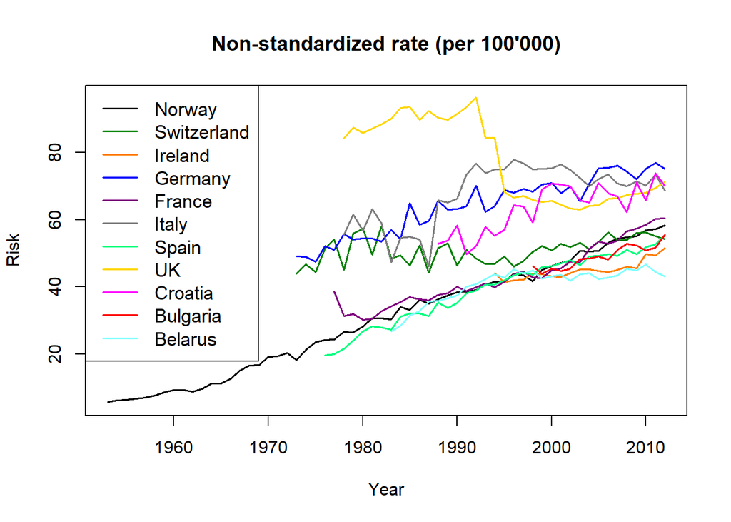

```r
# Visualizzazione dei 3 paesi migliori e peggiori per HDI (2012)
# In aggiunta anche Germania, Francia, Italia, Spagna, Regno Ubito
c2_list = c("Norway", "Switzerland", "Ireland", "Germany", "France", "Italy",
            "Spain", "UK", "Croatia", "Bulgaria", "Belarus")

colors = colorRamps::primary.colors(length(c2_list))
colors[4] = "blue"
colors[8] = "gold"
colors[10] = "red"

nor_m = crude[which(crude$Country=="Norway"), ]
plot(nor_m$YEAR, nor_m$Crude, type="l",
     ylim=c(min(crude$Crude), max(crude$Crude)),
     xlim=c(min(crude$YEAR), max(crude$YEAR)),
     xlab="Year", ylab="Risk", main="Non-standardized rate (per 100'000)",
     lwd=1.8)

for (country in c2_list){
  temp = crude[which(crude$Country==country), ]
  lines(temp$YEAR, temp$Crude,
        col=colors[match(country, c2_list)],
        lwd=1.8)
}
legend("topleft", legend=c2_list,
       col=colors, lty=1, lwd=1.8, cex=1.1)
```

Visualizzazione dei valori standardizzati.

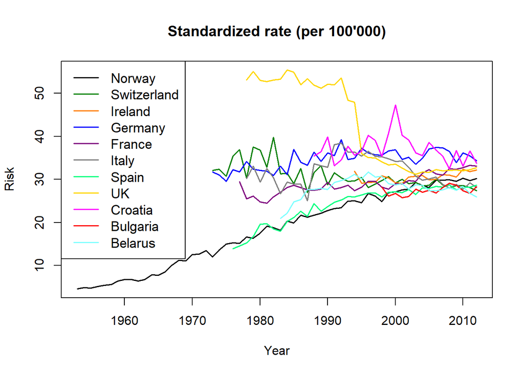

```r
### Plot con i valori standardizzati
nor_m_std = temp_standard[which(temp_standard$Country=="Norway"), ]
plot(nor_m_std$YEAR, nor_m_std$ASR_vect, type="l",
     ylim=c(min(temp_standard$ASR_vect), max(temp_standard$ASR_vect)),
     xlab="Year", ylab="Risk", main="Standardized rate (per 100'000)",
     lwd=1.8)

for (country in c2_list){
  temp = temp_standard[which(temp_standard$Country==country), ]
  lines(temp$YEAR, temp$ASR_vect, col=colors[match(country, c2_list)],
        lwd=1.8)
}
legend("topleft", legend=c2_list,
       col=colors, lty=1, lwd=1.8, cex=1.1)
```

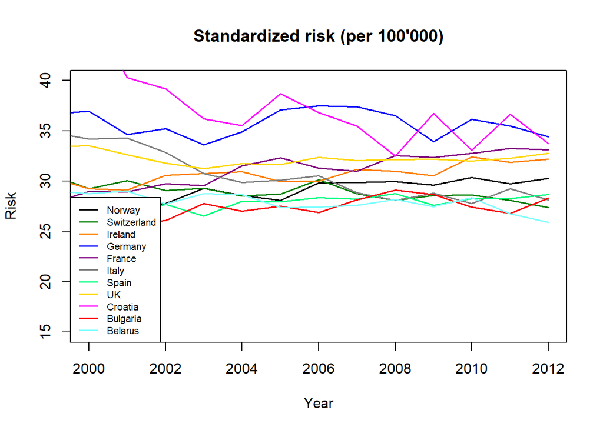

```r
# zoom
nor_m_std = temp_standard[which(temp_standard$Country=="Norway"), ]
plot(nor_m_std$YEAR, nor_m_std$ASR_vect, type="l",
     ylim=c(15, 40), xlim=c(2000, 2012),
     xlab="Year", ylab="Risk", main="Standardized risk (per 100'000)",
     lwd=1.8)

for (country in c2_list){
  temp = temp_standard[which(temp_standard$Country==country), ]
  lines(temp$YEAR, temp$ASR_vect, col=colors[match(country, c2_list)],
        lwd=1.8)
}
legend("bottomleft", legend=c2_list,
       col=colors, lty=1, lwd=1.8, cex=0.7)
```

## Stratificazione per età e SIR

Si crea un nuovo dataset con il numero atteso di casi di tumore al polmone stratificato per età.

```r
# Creazione del dataset con i range di età per riga e la popolazione standard
df = matrix(, nrow=0, ncol=5)

colnames(df) = c("age_group", "country", "year", "cases", "pop")
for (j in 24:41){
  for (i in 1:nrow(full)){
    vect = c()
    vect[1] = colnames(full[j])
    vect[2] = as.character(full[i, 1])
    vect[3] = full[i, 2]
    vect[4] = full[i, j-20]
    vect[5] = full[i, j]
    df = rbind(df, vect)
  }
}

df = as.data.frame(df)
df$pop = as.integer(as.character(df$pop))
df$age_group = gsub('P', '', df$age_group)
std_world_pop18classes$Age.group = gsub('-', '_', std_world_pop18classes$Age.group)
std_world_pop18classes$Age.group = gsub('+', '', std_world_pop18classes$Age.group, fixed = TRUE)
colnames(std_world_pop18classes) = c("group_age", "std_pop")

df = sqldf("SELECT age_group, country, year, cases, pop, std_pop
            FROM df, std_world_pop18classes
            WHERE age_group=group_age")

df$cases = as.integer(as.character(df$cases))
# Numero di tumori diviso le persone anno
df$cancer_expected = (df$cases / df$pop) * df$std_pop
```

Calcolo del SIR.

```r
#---- SIR paesi di riferimenti ----
sir_tot = c()
asr_tot = matrix(, nrow=1, ncol=0)
asr_tot = as.data.frame(asr_tot)
for (country in c2_list){
  temp_df_country = assign(paste0("df_", country), df[which(df$country == country), ])
  temp_asr_country = aggregate(data.frame(cancer_expected=temp_df_country$cancer_expected,
                                          pop_world=temp_df_country$std_pop),
                               by=list(year=temp_df_country$year),
                               FUN=sum)
  temp_asr_country$asr = temp_asr_country$cancer_expected / temp_asr_country$pop_world
  temp_asr_country2 = assign(paste0("asr_", country), temp_asr_country)
  temp_sir_country = assign(paste0("sir_", country),
                            temp_asr_country2$asr[temp_asr_country2$year == 2012] /
                              temp_asr_country2$asr[temp_asr_country2$year == 1998])

  print(paste(country, "SIR:",
              temp_asr_country2$asr[temp_asr_country2$year == 2012] /
                temp_asr_country2$asr[temp_asr_country2$year == 1998]))

  sir_tot = append(sir_tot, temp_sir_country)
  temp = temp_asr_country[which(temp_asr_country$year==2012), ]
  asr_tot = cbind(asr_tot, temp[1, ncol(temp)])
}
```

```
## [1] "Norway SIR: 1.21834733698245"
## [1] "Switzerland SIR: 0.921884341586199"
## [1] "Ireland SIR: 1.04266761876378"
## [1] "Germany SIR: 0.965658969550126"
## [1] "France SIR: 1.17520969785388"
## [1] "Italy SIR: 0.79845590352271"
## [1] "Spain SIR: 1.10382603486556"
## [1] "UK SIR: 0.960669354468267"
## [1] "Croatia SIR: 0.954148979675244"
## [1] "Bulgaria SIR: 1.00354686632318"
## [1] "Belarus SIR: 0.841587455621624"
```

```r
# Rinomino il df con gli ASR del 2010
names(asr_tot) = c2_list
asr_tot = as.data.frame(t(asr_tot))
asr_tot = cbind(asr_tot, c2_list)
names(asr_tot) = c("ASR", "Country")
asr_tot = asr_tot[c(2,1)]
```

## Visualizzazione e modello di Poisson

Modello di Poisson con i contrasti tra il $2012$ e il $1998$. L’intervallo d’età 70-74 anni è preso come riferitmento.

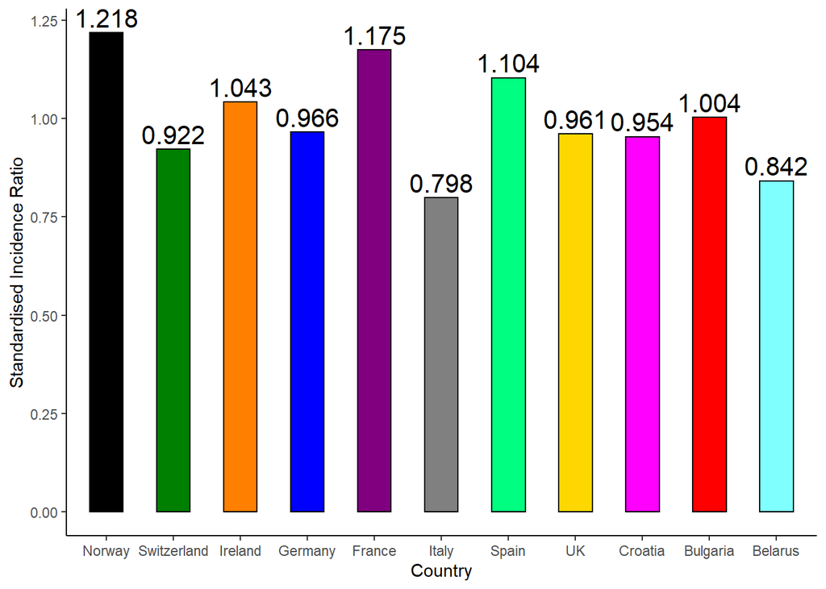

```r
# Bar Plot
tabb = data.frame(c2_list, sir_tot)

ggplot(tabb, aes(x=c2_list, y=sir_tot)) +
  geom_bar(stat="identity", width=0.5, color="black", fill=colors) +
  geom_text(aes(label=round(sir_tot, 3)), vjust=-0.3, color="black", size=5.5) +
  labs(x = "Country", y = "Standardised Incidence Ratio") +
  theme_classic() +
  scale_x_discrete(limits=c2_list)
```

```r
names(tabb) = c("Country", "SIR")


# Poisson
# Contrasti 2012 e 1998
for (country in c("Norway", "Italy", "Belarus")){
  temp_df = df[which(df$country==country), ]
  temp_df$year2012 = NA
  temp_df$year2012[temp_df$year==2012] = 1
  temp_df$year2012[temp_df$year==1998] = 0
  temp_df$age_group = as.factor(temp_df$age_group)
  temp_df = within(temp_df, age_group <- relevel(age_group, ref = "70_74"))

  model = glm(cases ~ year2012, offset=log(pop),
              data=temp_df[!is.na(temp_df), ], family="poisson")
  print(paste("------- Poisson summary for", country, "-------"))
  print(summary(model))

  print(exp(cbind("Incidence rate ratio" = coef(model),
                  confint.default(model, level=0.95))))
}
```

```
## [1] "------- Poisson summary for Norway -------"
##
## Call:
## glm(formula = cases ~ year2012, family = "poisson", data = temp_df[!is.na(temp_df),
##     ], offset = log(pop))
##
## Deviance Residuals:
##    Min      1Q  Median      3Q     Max
## -19.44  -16.57  -12.25   14.36   28.74
##
## Coefficients:
##             Estimate Std. Error z value Pr(>|z|)
## (Intercept) -7.78508    0.02329 -334.22   <2e-16 ***
## year2012     0.33783    0.02974   11.36   <2e-16 ***
## ---
## Signif. codes:  0 '***' 0.001 '**' 0.01 '*' 0.05 '.' 0.1 ' ' 1
##
## (Dispersion parameter for poisson family taken to be 1)
##
##     Null deviance: 11006  on 35  degrees of freedom
## Residual deviance: 10874  on 34  degrees of freedom
##   (7560 observations deleted due to missingness)
## AIC: 11047
##
## Number of Fisher Scoring iterations: 6
##
##             Incidence rate ratio        2.5 %       97.5 %
## (Intercept)         0.0004158937 0.0003973331 0.0004353212
## year2012            1.4018955154 1.3225210267 1.4860338674
## [1] "------- Poisson summary for Italy -------"
##
## Call:
## glm(formula = cases ~ year2012, family = "poisson", data = temp_df[!is.na(temp_df),
##     ], offset = log(pop))
##
## Deviance Residuals:
##    Min      1Q  Median      3Q     Max
## -25.21  -17.83  -13.75   16.24   35.21
##
## Coefficients:
```

[output cut: 32 more lines]

```
## ---
## Signif. codes:  0 '***' 0.001 '**' 0.01 '*' 0.05 '.' 0.1 ' ' 1
##
## (Dispersion parameter for poisson family taken to be 1)
##
##     Null deviance: 17031  on 35  degrees of freedom
## Residual deviance: 17027  on 34  degrees of freedom
##   (3780 observations deleted due to missingness)
## AIC: 17216
##
## Number of Fisher Scoring iterations: 6
##
##             Incidence rate ratio        2.5 %       97.5 %
## (Intercept)         0.0004487528 0.0004359414 0.0004619406
## year2012            0.9601578660 0.9204813485 1.0015446040
```

Contrasti tra classi d’età (primo e ultimo paese per HDI più l’Italia).

```r
# Contrasti fra classi d'età
for (country in c("Norway", "Italy", "Belarus")){
  temp_df = df[which(df$country==country), ]
  temp_df$year2012 = NA
  temp_df$year2012[temp_df$year==2012] = 1
  temp_df$year2012[temp_df$year==1998] = 0
  temp_df$age_group = as.factor(temp_df$age_group)
  temp_df = within(temp_df, age_group <- relevel(age_group, ref = "70_74"))

  model = glm(cases ~ age_group, data=temp_df[temp_df$year==2012, ], family="poisson")

  print(paste("------- Poisson summary for", country, "-------"))
  print(summary(model))
}
```

```
## [1] "------- Poisson summary for Norway -------"
##
## Call:
## glm(formula = cases ~ age_group, family = "poisson", data = temp_df[temp_df$year ==
##     2012, ])
##
## Deviance Residuals:
##  [1]  0  0  0  0  0  0  0  0  0  0  0  0  0  0  0  0  0  0
##
## Coefficients:
##                  Estimate Std. Error z value Pr(>|z|)
## (Intercept)     6.223e+00  4.454e-02 139.696  < 2e-16 ***
## age_group0_4   -2.953e+01  6.965e+04   0.000 0.999662
## age_group10_14 -2.953e+01  6.965e+04   0.000 0.999662
## age_group15_19 -5.529e+00  7.085e-01  -7.804 5.98e-15 ***
## age_group20_24 -6.223e+00  1.001e+00  -6.216 5.09e-10 ***
## age_group25_29 -6.223e+00  1.001e+00  -6.216 5.09e-10 ***
## age_group30_34 -4.431e+00  4.107e-01 -10.789  < 2e-16 ***
## age_group35_39 -4.143e+00  3.564e-01 -11.627  < 2e-16 ***
## age_group40_44 -3.045e+00  2.089e-01 -14.572  < 2e-16 ***
## age_group45_49 -2.180e+00  1.397e-01 -15.597  < 2e-16 ***
## age_group5_9   -2.953e+01  6.965e+04   0.000 0.999662
## age_group50_54 -1.478e+00  1.033e-01 -14.298  < 2e-16 ***
## age_group55_59 -8.519e-01  8.146e-02 -10.459  < 2e-16 ***
## age_group60_64 -2.437e-01  6.720e-02  -3.626 0.000287 ***
## age_group65_69  9.639e-02  6.153e-02   1.567 0.117212
## age_group75_79 -1.752e-01  6.594e-02  -2.657 0.007884 **
## age_group80_84 -2.957e-01  6.820e-02  -4.335 1.46e-05 ***
## age_group85    -7.213e-01  7.788e-02  -9.262  < 2e-16 ***
## ---
## Signif. codes:  0 '***' 0.001 '**' 0.01 '*' 0.05 '.' 0.1 ' ' 1
##
## (Dispersion parameter for poisson family taken to be 1)
##
##     Null deviance: 4.5457e+03  on 17  degrees of freedom
## Residual deviance: 4.5488e-10  on  0  degrees of freedom
## AIC: 121.94
##
## Number of Fisher Scoring iterations: 21
##
```

[output cut: 64 more lines]

```
## age_group60_64  1.216e-01  5.419e-02   2.244 0.024864 *
## age_group65_69 -2.012e-01  5.884e-02  -3.419 0.000628 ***
## age_group75_79 -3.824e-01  6.197e-02  -6.170 6.83e-10 ***
## age_group80_84 -9.391e-01  7.444e-02 -12.616  < 2e-16 ***
## age_group85    -1.987e+00  1.137e-01 -17.482  < 2e-16 ***
## ---
## Signif. codes:  0 '***' 0.001 '**' 0.01 '*' 0.05 '.' 0.1 ' ' 1
##
## (Dispersion parameter for poisson family taken to be 1)
##
##     Null deviance: 5.9517e+03  on 17  degrees of freedom
## Residual deviance: 4.5499e-10  on  0  degrees of freedom
## AIC: 130.35
##
## Number of Fisher Scoring iterations: 21
```

Contrasti fra tutti gli anni e classi d’età.

```r
# Contrasti fra tutti gli anni e classi d'età
for (country in c("Italy", "Belarus", "Norway")){
  temp_df = df[which(df$country==country), ]
  temp_df$age_group = as.factor(temp_df$age_group)
  temp_df = within(temp_df, age_group <- relevel(age_group, ref = "70_74"))

  model = glm(cases ~ as.factor(year) + age_group, data=temp_df,
              family="poisson", offset=log(pop))

  print(paste("------- Poisson summary for", country, "-------"))
  print(summary(model))
  print(exp(cbind("Incidence rate ratio" = coef(model),
                  confint.default(model, level=0.95))))
}
```

```
## [1] "------- Poisson summary for Italy -------"
##
## Call:
## glm(formula = cases ~ as.factor(year) + age_group, family = "poisson",
##     data = temp_df, offset = log(pop))
##
## Deviance Residuals:
##     Min       1Q   Median       3Q      Max
## -5.1420  -1.1003  -0.2190   0.9187   5.2964
##
## Coefficients:
##                       Estimate Std. Error  z value Pr(>|z|)
## (Intercept)          -6.075896   0.067308  -90.269  < 2e-16 ***
## as.factor(year)1979   0.090430   0.092374    0.979 0.327602
## as.factor(year)1980  -0.009630   0.094285   -0.102 0.918651
## as.factor(year)1981   0.086359   0.091853    0.940 0.347121
## as.factor(year)1982   0.003240   0.093487    0.035 0.972353
## as.factor(year)1983  -0.106721   0.087346   -1.222 0.221775
## as.factor(year)1984   0.027722   0.084866    0.327 0.743931
## as.factor(year)1985   0.017363   0.084779    0.205 0.837730
## as.factor(year)1986  -0.009523   0.084997   -0.112 0.910788
## as.factor(year)1987  -0.180892   0.087750   -2.061 0.039262 *
## as.factor(year)1988   0.127661   0.073266    1.742 0.081435 .
## as.factor(year)1989   0.114761   0.072748    1.578 0.114680
## as.factor(year)1990   0.120625   0.072647    1.660 0.096829 .
## as.factor(year)1991   0.286691   0.069490    4.126  3.7e-05 ***
## as.factor(year)1992   0.304107   0.069178    4.396  1.1e-05 ***
## as.factor(year)1993   0.254686   0.069136    3.684 0.000230 ***
## as.factor(year)1994   0.255486   0.069107    3.697 0.000218 ***
## as.factor(year)1995   0.242389   0.069105    3.508 0.000452 ***
## as.factor(year)1996   0.268134   0.069023    3.885 0.000102 ***
## as.factor(year)1997   0.244167   0.069045    3.536 0.000406 ***
## as.factor(year)1998   0.255266   0.068740    3.714 0.000204 ***
## as.factor(year)1999   0.246832   0.068731    3.591 0.000329 ***
## as.factor(year)2000   0.240525   0.068719    3.500 0.000465 ***
## as.factor(year)2001   0.245323   0.068687    3.572 0.000355 ***
## as.factor(year)2002   0.212856   0.068714    3.098 0.001950 **
## as.factor(year)2003   0.169953   0.068728    2.473 0.013405 *
## as.factor(year)2004   0.131292   0.068764    1.909 0.056223 .
## as.factor(year)2005   0.157556   0.068696    2.294 0.021817 *
```

[output cut: 369 more lines]

```
## age_group15_19              9.142053e-04  6.125550e-04  1.364402e-03
## age_group20_24              1.484886e-03  1.084435e-03  2.033211e-03
## age_group25_29              2.433963e-03  1.907624e-03  3.105526e-03
## age_group30_34              4.890266e-03  4.120016e-03  5.804516e-03
## age_group35_39              1.557421e-02  1.412892e-02  1.716734e-02
## age_group40_44              4.057428e-02  3.810282e-02  4.320604e-02
## age_group45_49              1.029016e-01  9.861365e-02  1.073761e-01
## age_group5_9                7.673455e-05  1.918924e-05  3.068486e-04
## age_group50_54              2.165945e-01  2.096760e-01  2.237412e-01
## age_group55_59              3.917299e-01  3.812214e-01  4.025282e-01
## age_group60_64              6.182413e-01  6.032972e-01  6.335556e-01
## age_group65_69              8.401012e-01  8.206709e-01  8.599915e-01
## age_group75_79              1.017390e+00  9.927235e-01  1.042670e+00
## age_group80_84              8.464677e-01  8.223073e-01  8.713378e-01
## age_group85                 5.298155e-01  5.100822e-01  5.503123e-01
```

Visualizzazione dell’IRR in Norvegia dal 1953, primo anno disponibile e preso come riferimento.

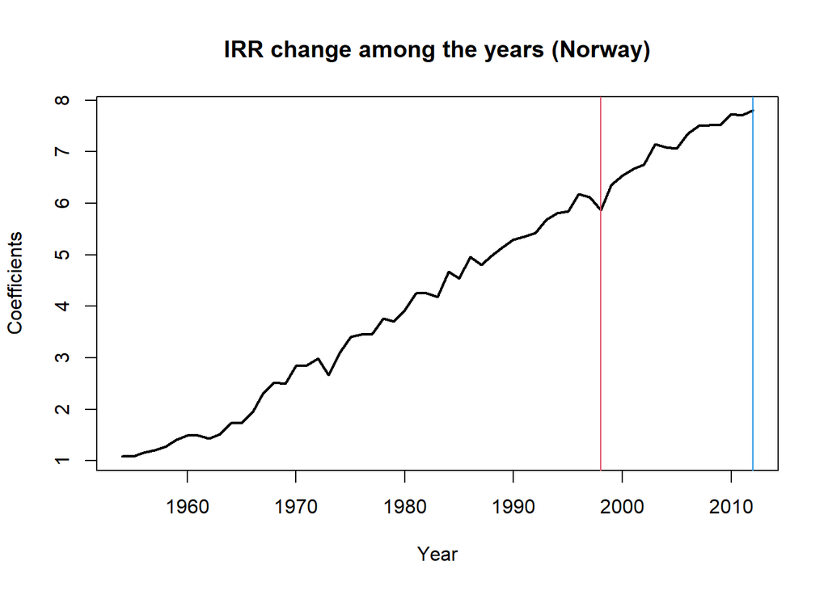

```r
# IRR nei diversi anni per la Norvegia (1953 anno di riferimento)
model_estimates = model$coefficients[c(2:60)]
year = seq(1954, 2012)
model_estimates = as.data.frame(model_estimates)
model_estimates = cbind(model_estimates, year)
plot(model_estimates$year, exp(model_estimates$model_estimates),
     ylab="Coefficients", xlab="Year", type="l", lwd=2,
     main="IRR change among the years (Norway)")
abline(v=1998, col=2)
abline(v=2012, col=4)
```